# Logfile_Kasthury

Kasthury Inparajah

2025-05-27

# Proteomics

## Introduction of this project

What are we going to do in this project?

## The article

Write about the article, some background information, keynotes

## Data

What is the data and where is it from?

## 23-4-2025

### Finding related articles

write about assignments and found articles and overview of it

## 24-4-2025

**“High-throughput proteomics: a methodological mini-review”** **“Understudied proteins: opportunities and challenges for functional proteomics”**

## Install libraries

```
## Bioconductor version 3.21 (BiocManager 1.30.25), R 4.5.0 (2025-04-11 ucrt)
```

```
## Installation paths not writeable, unable to update packages
##   path: C:/Program Files/R/R-4.5.0/library
##   packages:
##     lattice, mgcv
```

```
## Old packages: 'data.table', 'openssl'
```

[output not shown]

[output not shown]

[output not shown]

[output not shown]

[output not shown]

[output not shown]

[output not shown]

[output not shown]

[output not shown]

[output not shown]

[output not shown]

[output not shown]

```r
if (!requireNamespace("BiocManager", quietly = TRUE))
    install.packages("BiocManager")

BiocManager::install("pathview")
```

## Load libraries

[output not shown]

[output not shown]

[output not shown]

## EDA

### **Transcriptomics**

```
##          Sample M1_ctrl_Epcam M2_ctrl_Epcam M3_ctrl_Epcam M4_ctrl_Epcam
## 1 0610009B22Rik           266            41            79            46
## 2 0610010K14Rik            21             3             3             1
## 3 0610012G03Rik           276            41            93            74
## 4 0610030E20Rik           416            88           132            84
## 5 0610038B21Rik            16             1             4             9
## 6 0610040J01Rik           765           144           236           120
##   M1_EVs_Epcam M2_EVs_Epcam M3_EVs_Epcam M4_EVs_Epcam M1_SFs_Epcam M2_SFs_Epcam
## 1          100           59          171          277          198           14
## 2            7            2           17           24           19            2
## 3           96          113          273          304          254           30
## 4          163          106          372          494          443           36
## 5            3            1            6            6           12            1
## 6          221          170          584          661          692           75
##   M3_SFs_Epcam M4_SFs_Epcam M1_OGN_Epcam M2_OGN_Epcam M3_OGN_Epcam M4_OGN_Epcam
```

[output cut: 27 more lines]

### **Proteomics**

```
## # A tibble: 6 × 12
##   PG.ProteinGroups  PG.Genes      `2021-36_EV1`    `2021-36_SF1`   `2021-36_SF2`
##   <chr>             <chr>         <chr>            <chr>           <chr>
## 1 <NA>              COUNT         1906             1975            1676
## 2 A0A0B4J2D5;P0DPI2 GATD3B;GATD3A Filtered         362.8529663085… Filtered
## 3 A0AVT1            UBA6          2634.720703125   2805.660888671… 2079.8071289…
## 4 A1L4H1            SSC5D         317746.125       10269.7578125   11300.503906…
## 5 A4D0V7            CPED1         Filtered         1885.836303710… 3033.9199218…
## 6 A5YKK6            CNOT1         11153.7802734375 12914.220703125 9238.0917968…
## # ℹ 7 more variables: `2021-36_SF3` <chr>, `2021-42_EV1` <chr>,
## #   `2021-42_EV2` <chr>, `2021-42_EV3` <chr>, `2021-42_EV4` <chr>,
## #   `2021-42_SF1` <chr>, `2021-42_SF2` <chr>
```

It is noticeable that a lot of values are “Filtered”. This makes it difficult to include these data when we analyse the dataset, thus why we need to impute these values.

Besides the filtered data, some samples with numerical values, e.g. from column *2021-36_EV1* are characters instead of numbers.

Now we need to check if the data has any duplicates for the proteins or genes columns. This is crucial because duplicates might influence future analysis and referring to a specific gene becomes almost impossible.

```
## [1] TRUE
```

The check for duplicates in the genes has returned positive, this means that the gene column has duplicates.

```
## [1] FALSE
```

The check for duplicates in the proteins has returned negative, this means that the proteins column does not contain any duplicates.

Let’s see which gene(s) are duplicated and how many times:

```
## [1] "TMPO"
```

```
##
## TMPO
##    2
```

The gene “TMPO” is 2x duplicated. As a solution for this problem, we can make unique rownames with the gene name added by the times it is duplicated.

Let’s make a subset of the dataset divided in EV (extracellular vesicles) and SF (soluble factors).

We now have to remove the metadata from the subset for further analysis e.g. PCA plots.

After we have removed the metadata, we have to change the datatype to numeric. But we first need to change the filtered values to NA.

Since the dataset has characters instead of numbers, we have to change the datatype.

Now that we have changed the datatype, we can impute the NA’s.

We are now going to do a Log2-transformation because the data is usually very skewed (large spread and not normally distributed). Log2 helps normalize the data and makes PCA more reliable.

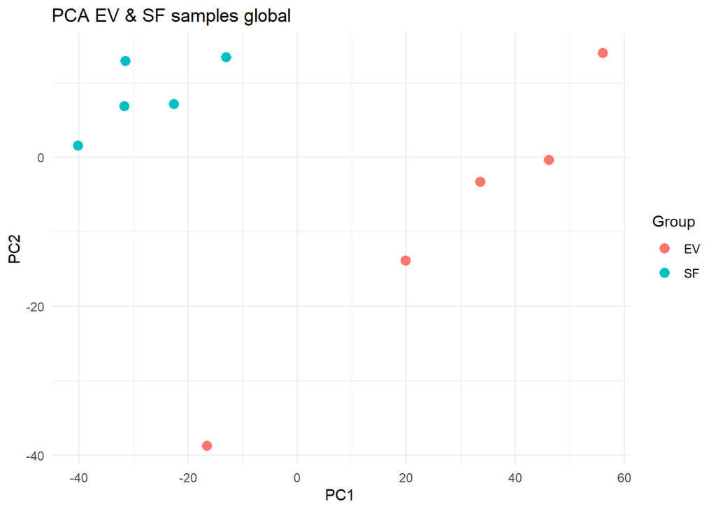

This PCA plot only depicts the difference between EV and SF but not the difference within the groups itself.

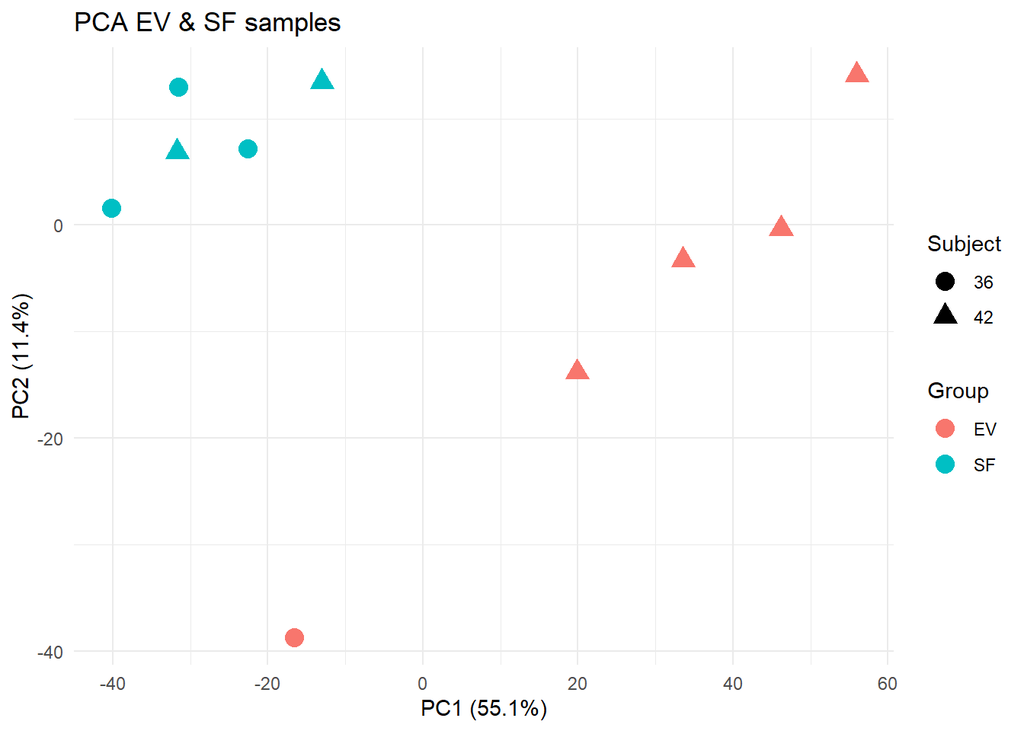

This PCA plot depicts the PCA scores of the data. Although there is nothing standing out from this plot, the difference between 36_EV and 42_EV is quite big.

## **Pathway analysis**

Now that we have started with the pathway analysis of the proteins, the first step we have to make is to transpose the names of the genes to the standard ID.

Since our dataset contains data from humans and mice, we are going to do a pathway analysis on both of them. We start with the human pathway.

```
##   SYMBOL ENTREZID
## 4   UBA6    55236
## 5  SSC5D   284297
## 6  CPED1    79974
## 7  CNOT1    23019
## 8    PGP   283871
## 9 TUBAL3    79861
```

```
## Reading KEGG annotation online: "https://rest.kegg.jp/link/hsa/pathway"...
```

```
## Reading KEGG annotation online: "https://rest.kegg.jp/list/pathway/hsa"...
```

```
##                                category                      subcategory
## hsa01200                     Metabolism         Global and overview maps
## hsa03050 Genetic Information Processing Folding, sorting and degradation
## hsa01230                     Metabolism         Global and overview maps
## hsa05171                 Human Diseases        Infectious disease: viral
## hsa04144             Cellular Processes         Transport and catabolism
## hsa04610             Organismal Systems                    Immune system
##                ID                         Description GeneRatio  BgRatio
## hsa01200 hsa01200                   Carbon metabolism   71/1514 117/8866
## hsa03050 hsa03050                          Proteasome   38/1514  46/8866
## hsa01230 hsa01230         Biosynthesis of amino acids   48/1514  75/8866
## hsa05171 hsa05171      Coronavirus disease - COVID-19   96/1514 238/8866
## hsa04144 hsa04144                         Endocytosis   93/1514 252/8866
## hsa04610 hsa04610 Complement and coagulation cascades   46/1514  88/8866
##          RichFactor FoldEnrichment    zScore       pvalue     p.adjust
## hsa01200  0.6068376       3.553647 12.617526 1.971054e-26 6.800135e-24
## hsa03050  0.8260870       4.837574 11.841342 2.890902e-22 4.986806e-20
## hsa01230  0.6400000       3.747847 10.844351 1.153571e-19 1.326606e-17
## hsa05171  0.4033613       2.362088  9.665809 6.234419e-18 5.377186e-16
## hsa04144  0.3690476       2.161147  8.485638 1.582436e-14 1.091881e-12
## hsa04610  0.5227273       3.061096  8.817418 3.776436e-14 2.171450e-12
##                qvalue
## hsa01200 4.730529e-24
## hsa03050 3.469082e-20
## hsa01230 9.228567e-18
## hsa05171 3.740651e-16
## hsa04144 7.595695e-13
## hsa04610 1.510574e-12
##                                                                                                                                                                                                                                                                                                          …
## hsa01200                                                                                                                                                       283871/26227/1431/3417/25796/9563/2746/2806/5230/847/226/259…
## hsa03050                                                                                                                                                                                                                                                                                                 …
## hsa01230                                                                                                                                                                                                                                                                           587/26227/1431/3417/50…
## hsa05171                      8829/2162/1956/2147/715/629/718/727/2243/2244/2266/735/4312/…
## hsa04144 9146/10095/10109/10094/10092/27243/8724/6643/9525/9559/161/1…
## hsa04610                                                                                                                                                                                                                                                                                          2162/21…
##          Count
## hsa01200    71
## hsa03050    38
## hsa01230    48
## hsa05171    96
## hsa04144    93
## hsa04610    46
```

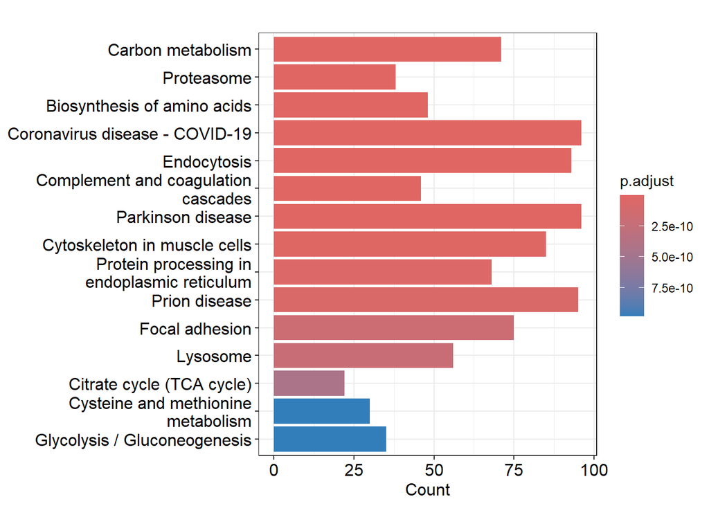

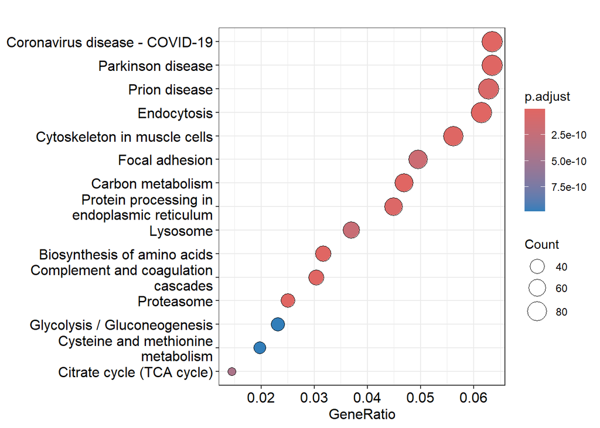

```
##     SYMBOL ENTREZID
## 298     F2    14061
## 301     F9    14071
## 302    F10    14058
## 313     C3    12266
## 339     C9    12279
## 545     C7   109828
```

```
## Reading KEGG annotation online: "https://rest.kegg.jp/link/mmu/pathway"...
```

```
## Reading KEGG annotation online: "https://rest.kegg.jp/list/pathway/mmu"...
```

```
##                    category               subcategory       ID
## mmu04610 Organismal Systems             Immune system mmu04610
## mmu05171     Human Diseases Infectious disease: viral mmu05171
## mmu05322     Human Diseases            Immune disease mmu05322
## mmu04810 Cellular Processes             Cell motility mmu04810
##                                  Description GeneRatio  BgRatio RichFactor
## mmu04610 Complement and coagulation cascades       8/8  94/9577 0.08510638
## mmu05171      Coronavirus disease - COVID-19       4/8 334/9577 0.01197605
## mmu05322        Systemic lupus erythematosus       3/8 150/9577 0.02000000
## mmu04810    Regulation of actin cytoskeleton       3/8 234/9577 0.01282051
##          FoldEnrichment    zScore       pvalue     p.adjust       qvalue
## mmu04610      101.88298 28.419258 6.360754e-17 1.399366e-15 1.004330e-15
## mmu05171       14.33683  7.173367 9.101441e-05 1.001159e-03 7.185349e-04
## mmu05322       23.94250  8.188482 1.990945e-04 1.460026e-03 1.047866e-03
## mmu04810       15.34776  6.424695 7.364324e-04 4.050378e-03 2.906970e-03
##                                                    geneID Count
## mmu04610 14061/14071/14058/12266/12279/109828/14067/14066     8
## mmu05171                         14061/12266/12279/109828     4
## mmu05322                               12266/12279/109828     3
## mmu04810                               14061/12279/109828     3
```

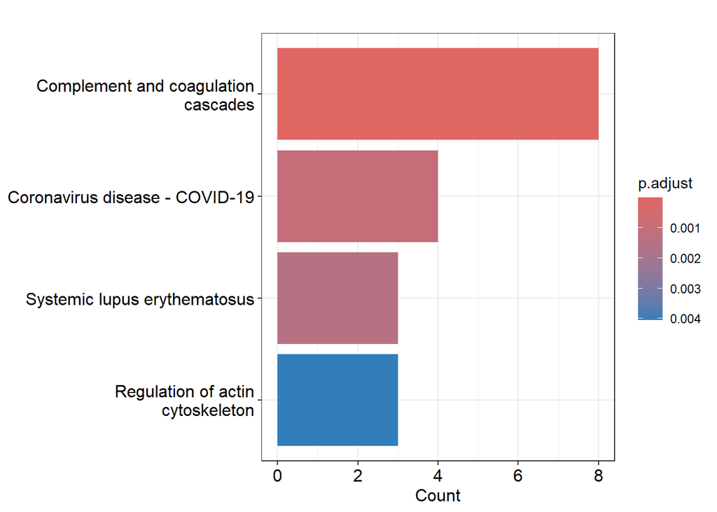

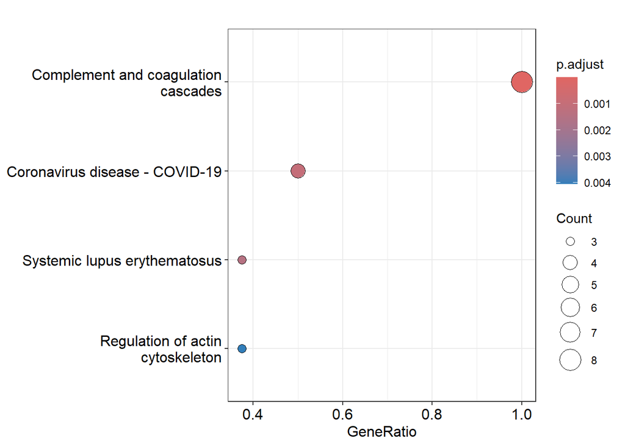

## Dataframe complete genes

But first of all, we are going to remove unesseccary data.

```r
## EV df
## Remove counts (row)
ev_data_rm_counts <- ev_data[-c(1), ]

## Remove protein and genes (column)
ev_data_rm_col_row <- ev_data_rm_counts[-c(1, 2) ]

## SF df
## Remove counts (row)
sf_data_rm_counts <- sf_data[-c(1), ]

## Remove protein and genes (column)
sf_data_rm_col_row <- sf_data_rm_counts[-c(1, 2) ]
```

As we have removed the the uneccessary row and colums, we now have to change the “filtered” or “NaN” values to NA.

```r
# For EV
ev_data_rm_col_row[ev_data_rm_col_row == "Filtered"] <- NA
ev_data_rm_col_row[ev_data_rm_col_row == ""] <- NA

# For SF
sf_data_rm_col_row[sf_data_rm_col_row == "Filtered"] <- NA
sf_data_rm_col_row[sf_data_rm_col_row == ""] <- NA
```

Let’s extract the gene rows from the df (ev_data_rm_counts and sf_data_rm_counts) to add them later.

```r
sf_genes <- sf_data_rm_counts[c(2)]

ev_genes <- ev_data_rm_counts[c(2)]
```

Now we make an index to see which rows (which are complete) are needed for our new df.

```r
# Make df numeric
ev_data_num <- as.data.frame(lapply(ev_data_rm_col_row, as.numeric))
sf_data_num <- as.data.frame(lapply(sf_data_rm_col_row, as.numeric))

ev_data_num <- cbind(ev_genes, ev_data_num)
sf_data_num <- cbind(sf_genes, sf_data_num)

# Make an index to see which rows we need
complete_genes_ev <- which(rowSums(is.na(ev_data_num)) == 0)
complete_genes_sf <- which(rowSums(is.na(sf_data_num)) == 0)

# Select the rows and make new df
df_complete_genes_ev <- ev_data_num[complete_genes_ev, , drop = FALSE]
df_complete_genes_sf <- sf_data_num[complete_genes_sf, , drop = FALSE]
```

Let’s do the same to genes which miss 1 value.

```r
# Make df numeric
ev_data_num <- as.data.frame(lapply(ev_data_rm_col_row, as.numeric))
sf_data_num <- as.data.frame(lapply(sf_data_rm_col_row, as.numeric))

ev_data_num <- cbind(ev_genes, ev_data_num)
sf_data_num <- cbind(sf_genes, sf_data_num)

# Make an index to see which rows we need
almost_complete_genes_ev <- which(rowSums(is.na(ev_data_num)) == 1)
almost_complete_genes_sf <- which(rowSums(is.na(sf_data_num)) == 1)

# Select the rows and make new df
df_almost_complete_genes_ev <- ev_data_num[almost_complete_genes_ev, , drop = FALSE]
df_almost_complete_genes_sf <- sf_data_num[almost_complete_genes_sf, , drop = FALSE]
```

```r
# For EV
ev_imputed2 <- as.data.frame(lapply(df_almost_complete_genes_ev, function(x) {
  ifelse(is.na(x), mean(x, na.rm=TRUE), x)
}))

# For SF
sf_imputed2 <- as.data.frame(lapply(df_almost_complete_genes_sf, function(x) {
  ifelse(is.na(x), mean(x, na.rm=TRUE), x)
}))
```

Now we can start with RLE normalisation, but before that, we need to split the gene column from the data and add then as rownames, therefore we also need to make a matrix from the data

```r
# Complete data

# EV data
ev_complete_matrix <- as.matrix(df_complete_genes_ev[, -1])
rownames(ev_complete_matrix) <- df_complete_genes_ev[, "PG.Genes"]

# SF data
sf_complete_matrix <- as.matrix(df_complete_genes_sf[, -1])
rownames(sf_complete_matrix) <- df_complete_genes_sf[, "PG.Genes"]

# Imputed data

# EV data
ev_matrix <- as.matrix(ev_imputed2[, -1])
rownames(ev_matrix) <- ev_imputed2[, "PG.Genes"]

# SF data
sf_matrix <- as.matrix(sf_imputed2[, -1])
rownames(sf_matrix) <- sf_imputed2[, "PG.Genes"]
```

We can now start with RLE normalisation

```r
# Geometrical mean
geo_mean <- function(x) exp(mean(log(x[x > 0])))
ev_geom_means <- apply(ev_complete_matrix, 1, geo_mean)

geo_mean <- function(x) exp(mean(log(x[x > 0])))
sf_geom_means <- apply(sf_complete_matrix, 1, geo_mean)

# Logratio
ev_complete_log_ratios <- log(ev_complete_matrix / ev_geom_means)
sf_complete_log_ratios <- log(sf_complete_matrix / sf_geom_means)

# Size factors
sf_complete_size_factors <- apply(sf_complete_log_ratios, 2, median, na.rm = TRUE)
sf_complete_size_factors <- exp(sf_complete_size_factors)

ev_complete_size_factors <- apply(ev_complete_log_ratios, 2, median, na.rm = TRUE)
ev_complete_size_factors <- exp(ev_complete_size_factors)

# Normalize data
ev_complete_normalized <- sweep(ev_complete_matrix, 2, ev_complete_size_factors, "/")
sf_complete_normalized <- sweep(sf_complete_matrix, 2, sf_complete_size_factors, "/")

# Add genename back to data
ev_complete_normalized_df <- cbind(PG.Genes = rownames(ev_complete_matrix), as.data.frame(ev_complete_normalized))

sf_complete_normalized_df <- cbind(PG.Genes = rownames(sf_complete_matrix), as.data.frame(sf_complete_normalized))
```

```r
# Geometrical mean
geo_mean <- function(x) exp(mean(log(x[x > 0])))
ev_geom_means <- apply(ev_matrix, 1, geo_mean)

geo_mean <- function(x) exp(mean(log(x[x > 0])))
sf_geom_means <- apply(sf_matrix, 1, geo_mean)

# Logratio
ev_log_ratios <- log(ev_matrix / ev_geom_means)
sf_log_ratios <- log(sf_matrix / sf_geom_means)

# Size factors
sf_size_factors <- apply(sf_log_ratios, 2, median, na.rm = TRUE)
sf_size_factors <- exp(sf_size_factors)

ev_size_factors <- apply(ev_log_ratios, 2, median, na.rm = TRUE)
ev_size_factors <- exp(ev_size_factors)

# Normalize data
ev_normalized <- sweep(ev_matrix, 2, ev_size_factors, "/")
sf_normalized <- sweep(sf_matrix, 2, sf_size_factors, "/")

# Add genename back to data
ev_normalized_df <- cbind(PG.Genes = rownames(ev_matrix), as.data.frame(ev_normalized))
sf_normalized_df <- cbind(PG.Genes = rownames(sf_matrix), as.data.frame(sf_normalized))
```

Now that we have the data normalised with RLE, we can make a PCA plot. Let’s start with the data which was already complete and was RLE normalised.

Since EV contains less data compared to SF, we are only going to do a PCA on the genes which are available in both data.

```r
# Find common genes
common_genes_complete <- intersect(rownames(ev_complete_normalized_df), rownames(sf_complete_normalized_df))

# Only genes available in both df's are conserved
ev_conserved_genes_complete <- ev_complete_normalized_df[common_genes_complete, -1]
sf_conserved_genes_complete <- sf_complete_normalized_df[common_genes_complete, -1]

# Transpose samples to rows
ev_pca_matrix_complete <- t(ev_conserved_genes_complete)
sf_pca_matrix_complete <- t(sf_conserved_genes_complete)

# Add label
ev_group_complete <- data.frame(sample = rownames(ev_pca_matrix_complete), group = "EV")
sf_group_complete <- data.frame(sample = rownames(sf_pca_matrix_complete), group = "SF")

# Combine data
combined_matrix_complete <- rbind(ev_pca_matrix_complete, sf_pca_matrix_complete)
group_info_complete <- rbind(ev_group_complete, sf_group_complete)

# Execute PCA
pca_result_complete <- prcomp(combined_matrix_complete, scale. = TRUE)

# Make PCA df
pca_df_complete <- as.data.frame(pca_result_complete$x)
pca_df_complete$group <- group_info_complete$group
pca_df_complete$sample <- rownames(pca_df_complete)
pca_df_complete$subject <- ifelse(grepl("36", pca_df_complete$sample), "36", "42")
```

Let’s make the PCA plot.

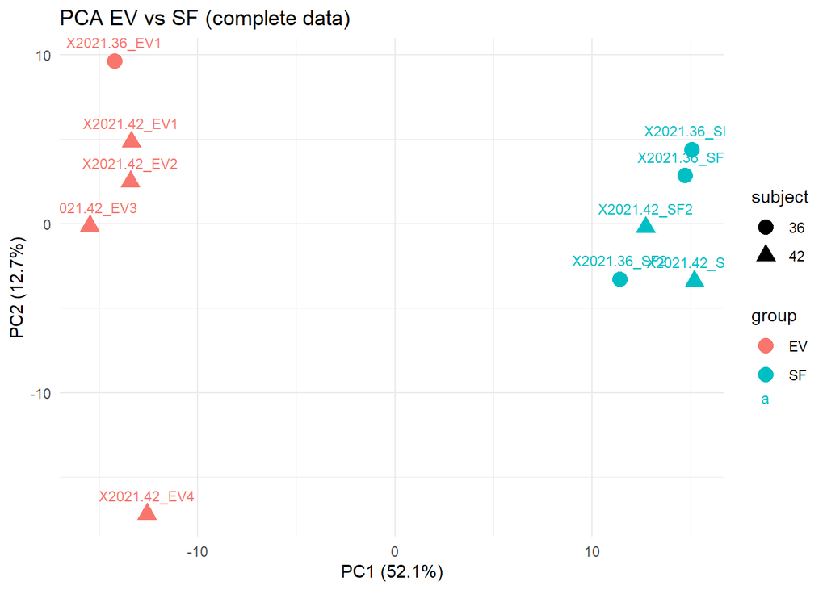

```r
library(ggplot2)

ggplot(pca_df_complete, aes(x = PC1, y = PC2, color = group, label = sample, shape=subject)) +
  geom_point(size = 4) +
  geom_text(vjust = -1.2, size = 3) +
  theme_minimal() +
  labs(title = "PCA EV vs SF (complete data)",
       x = paste0("PC1 (", round(summary(pca_result_complete)$importance[2, 1] * 100, 1), "%)"),
       y = paste0("PC2 (", round(summary(pca_result_complete)$importance[2, 2] * 100, 1), "%)"))
```

Now that we have made a PCA for the complete data, let’s make one for the imputed data.

```r
# Find common genes
common_genes_imputed <- intersect(rownames(ev_normalized_df), rownames(sf_normalized_df))

# Only genes available in both df's are conserved
ev_conserved_genes_imputed <- ev_normalized_df[common_genes_imputed, -1]
sf_conserved_genes_imputed <- sf_normalized_df[common_genes_imputed, -1]

# Transpose samples to rows
ev_pca_matrix_imputed <- t(ev_conserved_genes_imputed)
sf_pca_matrix_imputed <- t(sf_conserved_genes_imputed)

# Add label
ev_group_imputed <- data.frame(sample = rownames(ev_pca_matrix_imputed), group = "EV")
sf_group_imputed <- data.frame(sample = rownames(sf_pca_matrix_imputed), group = "SF")

# Combine data
combined_matrix_imputed <- rbind(ev_pca_matrix_imputed, sf_pca_matrix_imputed)
group_info_imputed <- rbind(ev_group_imputed, sf_group_imputed)

# Execute PCA
pca_result_imputed <- prcomp(combined_matrix_imputed, scale. = TRUE)

# Make PCA df
pca_df_imputed <- as.data.frame(pca_result_imputed$x)
pca_df_imputed$group <- group_info_imputed$group
pca_df_imputed$sample <- rownames(pca_df_imputed)
pca_df_imputed$subject <- ifelse(grepl("36", pca_df_imputed$sample), "36", "42")
```

Now we are going to make a plot for the imputed data.

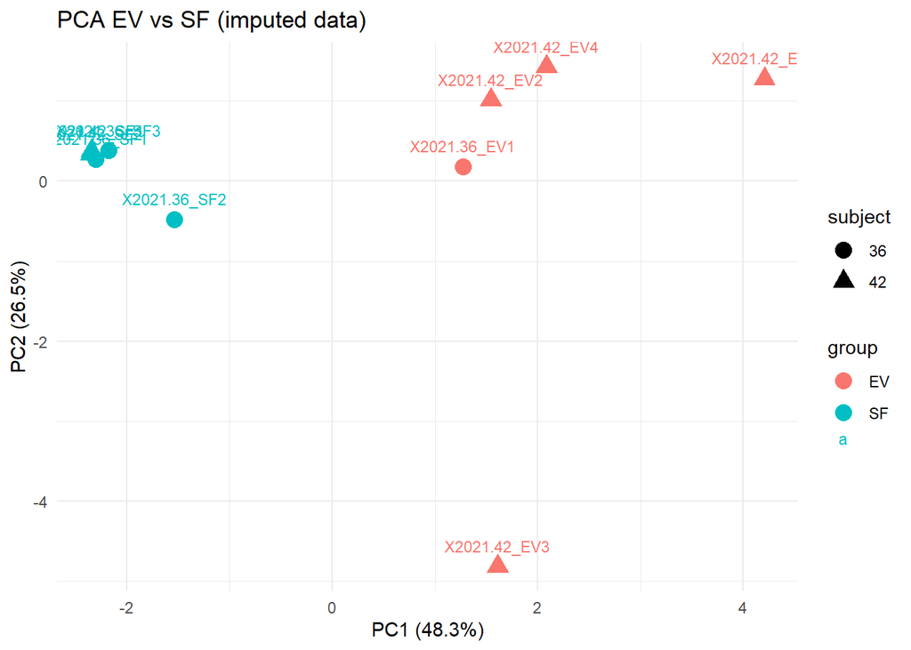

```r
library(ggplot2)

ggplot(pca_df_imputed, aes(x = PC1, y = PC2, color = group, label = sample, shape=subject)) +
  geom_point(size = 4) +
  geom_text(vjust = -1.2, size = 3) +
  theme_minimal() +
  labs(title = "PCA EV vs SF (imputed data)",
       x = paste0("PC1 (", round(summary(pca_result_imputed)$importance[2, 1] * 100, 1), "%)"),
       y = paste0("PC2 (", round(summary(pca_result_imputed)$importance[2, 2] * 100, 1), "%)"))
```

## **Pathway analysis Filtered data**

Just like we made a pathway analysis for the unfiltered data, we are now going to make one for the complete and imputed data. We are going to start with the complete data.

First of all, we have to transpose the names of the genes to the standard ID.

```r
# Get all genes
all_genes_complete <- ev_complete_normalized_df$PG.Genes

# Split genes which are in same row
genes_vector_complete <- unlist(strsplit(all_genes_complete, split = ";"))

# Get the unique genes
unique_genes_complete <- unique(genes_vector_complete)
```

As I have mentioned before, we have mice and human data. We start with the human pathway.

```r
gene_symbols_complete <- unique_genes_complete

# Translate to Entrez ID
entrez_ids_humans_complete <- bitr(gene_symbols_complete, fromType = "SYMBOL",
                   toType = "ENTREZID",
                   OrgDb = org.Hs.eg.db)
# Look at the translation
head(entrez_ids_humans_complete)
```

```
##   SYMBOL ENTREZID
## 1  SSC5D   284297
## 2 PSMD11     5717
## 3  CLIC1     1192
## 4  QSOX1     5768
## 5   AGRN   375790
## 6  SDCBP     6386
```

```r
# Make vector
entrez_ids_humans_complete <- entrez_ids_humans_complete$ENTREZID

# Make datatype numerical
entrez_ids_humans_complete <- na.omit(as.numeric(entrez_ids_humans_complete))
```

```r
# KEGG pathway analysis for humans
kegg_results_humans_complete <- enrichKEGG(gene = entrez_ids_humans_complete,
                           organism = "hsa",
                           pvalueCutoff = 0.05)
```

```
## Reading KEGG annotation online: "https://rest.kegg.jp/link/hsa/pathway"...
```

```
## Reading KEGG annotation online: "https://rest.kegg.jp/list/pathway/hsa"...
```

```r
# Results
head(kegg_results_humans_complete)
```

```
##                                      category
## hsa04820                   Cellular Processes
## hsa04512 Environmental Information Processing
## hsa04510                   Cellular Processes
## hsa05205                       Human Diseases
## hsa04145                   Cellular Processes
## hsa04151 Environmental Information Processing
##                                  subcategory       ID
## hsa04820                       Cell motility hsa04820
## hsa04512 Signaling molecules and interaction hsa04512
## hsa04510     Cellular community - eukaryotes hsa04510
## hsa05205                    Cancer: overview hsa05205
## hsa04145            Transport and catabolism hsa04145
## hsa04151                 Signal transduction hsa04151
##                           Description GeneRatio  BgRatio RichFactor
## hsa04820 Cytoskeleton in muscle cells    54/361 232/8866  0.2327586
## hsa04512     ECM-receptor interaction    35/361  89/8866  0.3932584
## hsa04510               Focal adhesion    46/361 203/8866  0.2266010
## hsa05205      Proteoglycans in cancer    38/361 204/8866  0.1862745
## hsa04145                    Phagosome    33/361 159/8866  0.2075472
## hsa04151   PI3K-Akt signaling pathway    46/361 362/8866  0.1270718
##          FoldEnrichment   zScore       pvalue     p.adjust       qvalue
## hsa04820       5.716449 14.99716 8.528310e-27 2.396455e-24 1.768502e-24
## hsa04512       9.658253 16.91251 4.100347e-26 5.760988e-24 4.251413e-24
## hsa04510       5.565220 13.55599 2.283667e-22 2.139035e-20 1.578535e-20
## hsa05205       4.574819 10.64182 1.391984e-15 9.778690e-14 7.216340e-14
## hsa04145       5.097267 10.74025 4.273479e-15 2.401695e-13 1.772369e-13
## hsa04151       3.120828  8.48797 3.213153e-12 1.433457e-10 1.057843e-10
##                                                                                                                                                                                                                                                                              geneID
## hsa04820 375790/1277/1281/1282/4000/2335/476/3690/3688/1290/2023/3685…
## hsa04512                                                                                           375790/3911/1277/1280/1282/2335/7448/3690/3688/3685/3912/7057/1278/1284/3678/3915/1291/1292/1293/960/3673/6382/3908/3371/284217/3675/6385/7058/1311/3913/3672/5649/3339/961/3910
## hsa04510                                              3911/81/2317/1277/1280/1282/2335/7448/3690/3688/3685/3912/70…
## hsa05205                                                                                     8324/1277/2335/7448/3690/3688/3685/1634/7057/1278/4313/3678/967/6237/3082/7430/960/3673/6382/2316/4478/5594/6385/6383/2817/5962/5501/8826/4060/60/998/22800/5879/71/3339/857/6093/2535
## hsa04145                                                                                                        9146/715/718/7037/3105/3690/3688/3685/203068/7057/3678/3916/3920/3673/811/821/7058/1311/5878/7879/60/5869/5879/71/10376/10383/10381/1778/8411/9341/7846/84790/84617
## hsa04151                                   3911/1277/1280/1282/2335/7448/3690/3688/3685/3320/3912/7057/…
##          Count
## hsa04820    54
## hsa04512    35
## hsa04510    46
## hsa05205    38
## hsa04145    33
## hsa04151    46
```

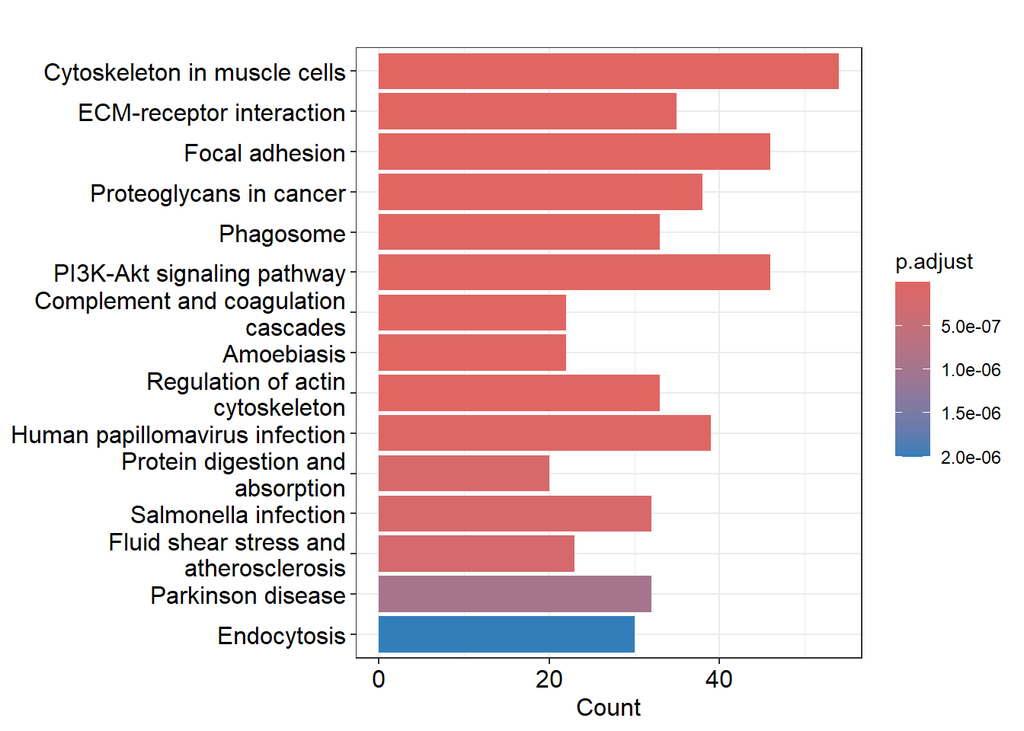

```r
# Visualisation
barplot(kegg_results_humans_complete, showCategory=15)
```

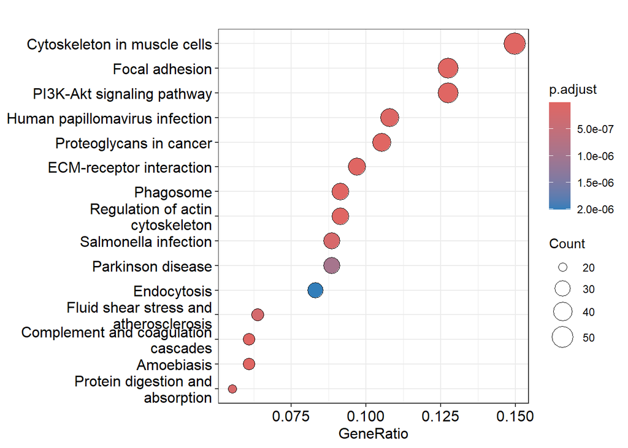

```r
dotplot(kegg_results_humans_complete, showCategory=15)
```

And now for the mice.

```r
gene_symbols_complete <- unique_genes_complete

# Translate to Entrez ID
entrez_ids_mice_complete <- bitr(gene_symbols_complete, fromType = "SYMBOL",
                   toType = "ENTREZID",
                   OrgDb = org.Mm.eg.db)
# Look at the translation
head(entrez_ids_mice_complete)
```

```
##     SYMBOL ENTREZID
## 37      F2    14061
## 46      C3    12266
## 179     F3    14066
```

```r
# Make vector
entrez_ids_mice_complete <- entrez_ids_mice_complete$ENTREZID

# Make datatype numerical
entrez_ids_mice_complete <- na.omit(as.numeric(entrez_ids_mice_complete))
```

```r
# KEGG pathway analysis for mice
kegg_results_mice_complete <- enrichKEGG(gene = entrez_ids_mice_complete,
                           organism = "mmu",
                           pvalueCutoff = 0.05)
```

```
## Reading KEGG annotation online: "https://rest.kegg.jp/link/mmu/pathway"...
```

```
## Reading KEGG annotation online: "https://rest.kegg.jp/list/pathway/mmu"...
```

```r
# Results
head(kegg_results_mice_complete)
```

```
##                                      category
## mmu04610                   Organismal Systems
## mmu05171                       Human Diseases
## mmu04080 Environmental Information Processing
##                                  subcategory       ID
## mmu04610                       Immune system mmu04610
## mmu05171           Infectious disease: viral mmu05171
## mmu04080 Signaling molecules and interaction mmu04080
##                                      Description GeneRatio  BgRatio  RichFactor
## mmu04610     Complement and coagulation cascades       3/3  94/9577 0.031914894
## mmu05171          Coronavirus disease - COVID-19       2/3 334/9577 0.005988024
## mmu04080 Neuroactive ligand-receptor interaction       2/3 392/9577 0.005102041
##          FoldEnrichment    zScore       pvalue     p.adjust       qvalue
## mmu04610      101.88298 17.398625 9.158961e-07 1.831792e-05 6.748708e-06
## mmu05171       19.11577  5.965262 3.554197e-03 3.251796e-02 1.198030e-02
## mmu04080       16.28741  5.470707 4.877694e-03 3.251796e-02 1.198030e-02
##                     geneID Count
## mmu04610 14061/12266/14066     3
## mmu05171       14061/12266     2
## mmu04080       14061/12266     2
```

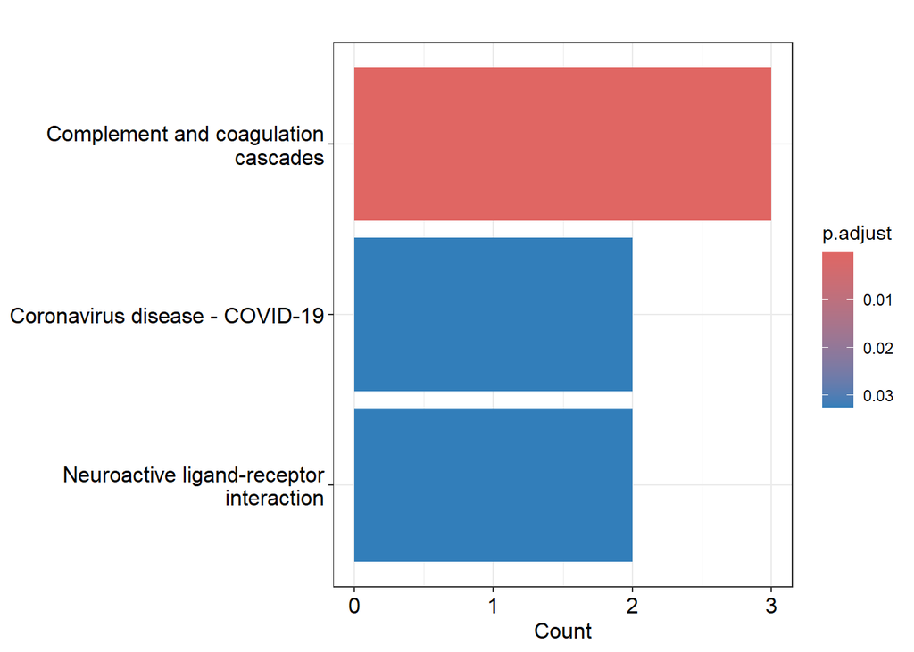

```r
# Visualisation
barplot(kegg_results_mice_complete, showCategory=15)
```

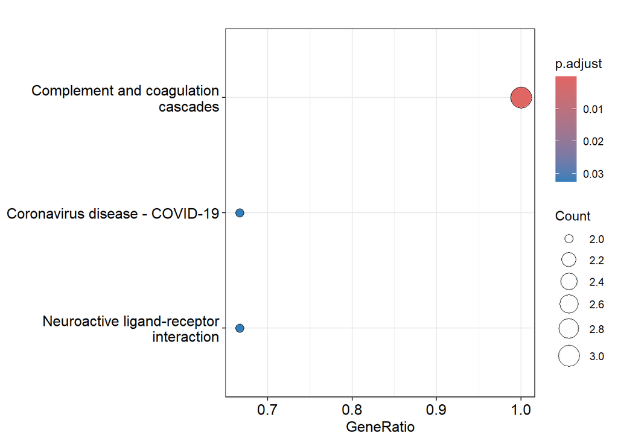

```r
dotplot(kegg_results_mice_complete, showCategory=15)
```

Let’s do the pathway analysis for the imputed data.

```r
# Get all genes
all_genes_imputed <- ev_normalized_df$PG.Genes

# Split genes which are in same row
genes_vector_imputed <- unlist(strsplit(all_genes_imputed, split = ";"))

# Get the unique genes
unique_genes_imputed <- unique(genes_vector_imputed)
```

```r
gene_symbols_imputed <- unique_genes_imputed

# Translate to Entrez ID
entrez_ids_humans_imputed <- bitr(gene_symbols_imputed, fromType = "SYMBOL",
                   toType = "ENTREZID",
                   OrgDb = org.Hs.eg.db)
# Look at the translation
head(entrez_ids_humans_imputed)
```

```
##   SYMBOL ENTREZID
## 1   IPO5     3843
## 2  PLOD2     5352
## 3   TPP1     1200
## 4 SCAMP3    10067
## 5 PGRMC2    10424
## 6  GPR37     2861
```

```r
# Make vector
entrez_ids_humans_imputed <- entrez_ids_humans_imputed$ENTREZID

# Make datatype numerical
entrez_ids_humans_imputed <- na.omit(as.numeric(entrez_ids_humans_imputed))
```

```r
# KEGG pathway analysis for humans
kegg_results_humans_imputed <- enrichKEGG(gene = entrez_ids_humans_imputed,
                           organism = "hsa",
                           pvalueCutoff = 0.05)
```

```
## Reading KEGG annotation online: "https://rest.kegg.jp/link/hsa/pathway"...
```

```
## Reading KEGG annotation online: "https://rest.kegg.jp/list/pathway/hsa"...
```

```r
# Results
head(kegg_results_humans_imputed)
```

```
##                                category                      subcategory
## hsa01200                     Metabolism         Global and overview maps
## hsa05171                 Human Diseases        Infectious disease: viral
## hsa04144             Cellular Processes         Transport and catabolism
## hsa01230                     Metabolism         Global and overview maps
## hsa03050 Genetic Information Processing Folding, sorting and degradation
## hsa05020                 Human Diseases        Neurodegenerative disease
##                ID                    Description GeneRatio  BgRatio RichFactor
## hsa01200 hsa01200              Carbon metabolism    13/150 117/8866 0.11111111
## hsa05171 hsa05171 Coronavirus disease - COVID-19    18/150 238/8866 0.07563025
## hsa04144 hsa04144                    Endocytosis    17/150 252/8866 0.06746032
## hsa01230 hsa01230    Biosynthesis of amino acids     9/150  75/8866 0.12000000
## hsa03050 hsa03050                     Proteasome     7/150  46/8866 0.15217391
## hsa05020 hsa05020                  Prion disease    15/150 278/8866 0.05395683
##          FoldEnrichment   zScore       pvalue     p.adjust       qvalue
## hsa01200       6.567407 7.952307 7.538537e-08 1.212397e-05 1.122864e-05
## hsa05171       4.470252 7.119030 9.398423e-08 1.212397e-05 1.122864e-05
## hsa04144       3.987354 6.311186 1.106789e-06 9.518383e-05 8.815475e-05
## hsa01230       7.092800 6.951120 4.333295e-06 2.794975e-04 2.588573e-04
## hsa03050       8.994493 7.131189 1.061996e-05 5.479898e-04 5.075221e-04
## hsa05020       3.189209 4.865079 6.918187e-05 2.974820e-03 2.755137e-03
##                                                                                            geneID
## hsa01200                          2746/2026/1738/5223/4200/7086/6472/6888/4190/4199/5214/50/29968
## hsa05171   2162/1956/727/735/730/6137/6134/6125/6158/6203/6193/6217/6194/6230/6231/4736/6142/6141
## hsa04144 27243/160/1956/3106/3107/378/5868/3799/832/10093/10097/57132/10552/1173/55737/6455/10938
## hsa01230                                               445/2026/5223/7086/6472/6888/5214/50/29968
## hsa03050                                                      5683/5685/5692/5693/5704/5687/11047
## hsa05020               727/735/506/730/5683/5685/5692/5693/10963/3799/5704/5687/7277/11047/347733
##          Count
## hsa01200    13
## hsa05171    18
## hsa04144    17
## hsa01230     9
## hsa03050     7
## hsa05020    15
```

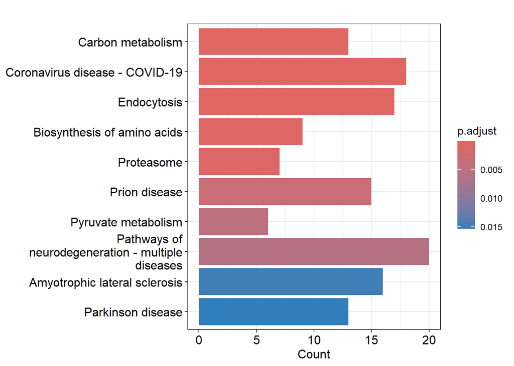

```r
# Visualisation
barplot(kegg_results_humans_imputed, showCategory=10)
```

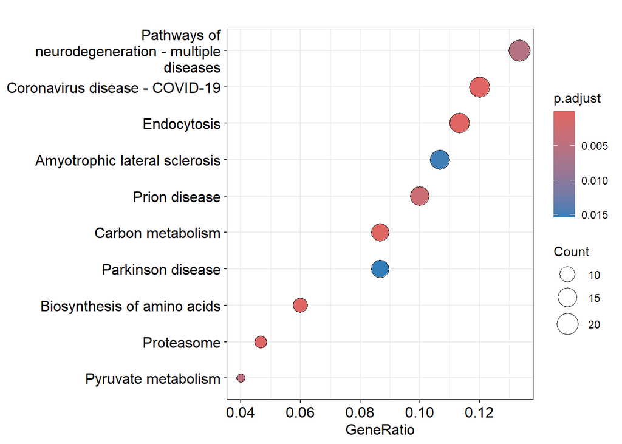

```r
dotplot(kegg_results_humans_imputed, showCategory=10)
```

And now for the mice.

```r
gene_symbols_imputed <- unique_genes_imputed

# Translate to Entrez ID
entrez_ids_mice_imputed <- bitr(gene_symbols_imputed, fromType = "SYMBOL",
                   toType = "ENTREZID",
                   OrgDb = org.Mm.eg.db)
# Look at the translation
head(entrez_ids_mice_imputed)
```

```
##    SYMBOL ENTREZID
## 41     C9    12279
## 66     C7   109828
## 68     F5    14067
```

```r
# Make vector
entrez_ids_mice_imputed <- entrez_ids_mice_imputed$ENTREZID

# Make datatype numerical
entrez_ids_mice_imputed <- na.omit(as.numeric(entrez_ids_mice_imputed))
```

```r
# KEGG pathway analysis for mice
kegg_results_mice_imputed <- enrichKEGG(gene = entrez_ids_mice_imputed,
                           organism = "mmu",
                           pvalueCutoff = 0.05)
```

```
## Reading KEGG annotation online: "https://rest.kegg.jp/link/mmu/pathway"...
```

```
## Reading KEGG annotation online: "https://rest.kegg.jp/list/pathway/mmu"...
```

```r
# Results
head(kegg_results_mice_imputed)
```

```
##                    category                   subcategory       ID
## mmu04610 Organismal Systems                 Immune system mmu04610
## mmu05322     Human Diseases                Immune disease mmu05322
## mmu04810 Cellular Processes                 Cell motility mmu04810
## mmu05020     Human Diseases     Neurodegenerative disease mmu05020
## mmu05171     Human Diseases     Infectious disease: viral mmu05171
## mmu05146     Human Diseases Infectious disease: parasitic mmu05146
##                                  Description GeneRatio  BgRatio  RichFactor
## mmu04610 Complement and coagulation cascades       3/3  94/9577 0.031914894
## mmu05322        Systemic lupus erythematosus       2/3 150/9577 0.013333333
## mmu04810    Regulation of actin cytoskeleton       2/3 234/9577 0.008547009
## mmu05020                       Prion disease       2/3 273/9577 0.007326007
## mmu05171      Coronavirus disease - COVID-19       2/3 334/9577 0.005988024
## mmu05146                          Amoebiasis       1/3 108/9577 0.009259259
##          FoldEnrichment    zScore       pvalue     p.adjust qvalue
## mmu04610      101.88298 17.398625 9.158961e-07 5.495377e-06     NA
## mmu05322       42.56444  9.082112 7.235802e-04 2.170741e-03     NA
## mmu04810       27.28490  7.205715 1.754716e-03 3.509432e-03     NA
## mmu05020       23.38706  6.642774 2.383232e-03 3.574848e-03     NA
## mmu05171       19.11577  5.965262 3.554197e-03 4.265036e-03     NA
## mmu05146       29.55864  5.283277 3.345443e-02 3.345443e-02     NA
##                      geneID Count
## mmu04610 12279/109828/14067     3
## mmu05322       12279/109828     2
## mmu04810       12279/109828     2
## mmu05020       12279/109828     2
## mmu05171       12279/109828     2
## mmu05146              12279     1
```

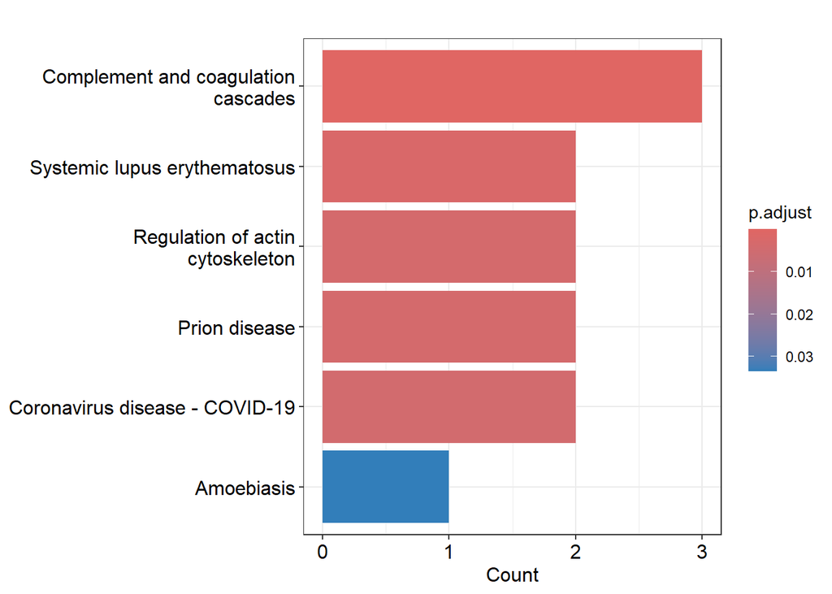

```r
# Visualisation
barplot(kegg_results_mice_imputed, showCategory=10)
```

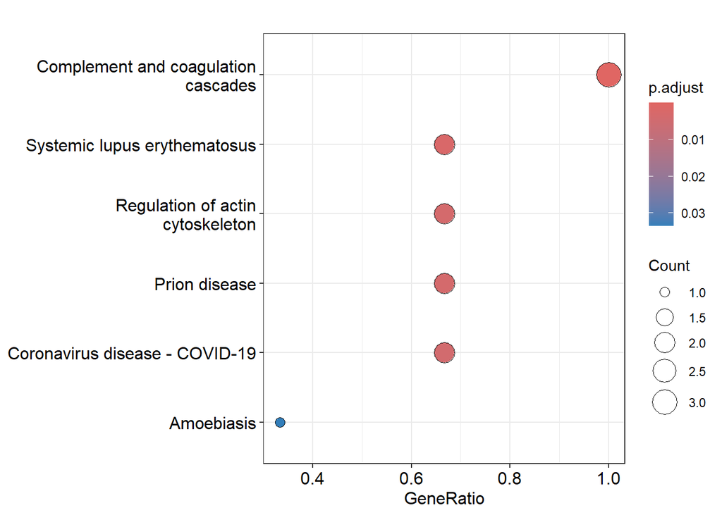

```r
dotplot(kegg_results_mice_imputed, showCategory=10)
```

We are now going to make a visualisation of the pathway. This code was written by my peer J. Jonker.

```r
library(pathview)
setwd("visualisation_pathway_proteomics/imputed_data/human")

pathview(
  gene.data = kegg_results_humans_imputed,
  pathway.id = "hsa05171",
  species = "hsa",
  out.suffix = "Coronavirus_disease_COVID-19"
)
```

```
## Info: Working in directory C:/Users/kasth/School/Programming/Year 2/Period 4 programming/omic_epithelial_cell_repair/Logfiles/visualisation_pathway_proteomics/imputed_data/human
```

```
## Info: Writing image file hsa05171.Coronavirus_disease_COVID-19.png
```

```r
# Chemokine signaling pathway
pathview(
  gene.data = kegg_results_humans_imputed,
  pathway.id = "hsa05171",
  species = "hsa",
  out.suffix = "Chemokine"
)
```

```
## Info: Working in directory C:/Users/kasth/School/Programming/Year 2/Period 4 programming/omic_epithelial_cell_repair/Logfiles/visualisation_pathway_proteomics/imputed_data/human
```

```
## Info: Writing image file hsa05171.Chemokine.png
```

Visualisation pathway mice complete data:

```r
setwd("visualisation_pathway_proteomics/complete_data/mice")

pathview(
  gene.data = kegg_results_mice_complete,
  pathway.id = "mmu05171",
  species = "mmu",
  out.suffix = "Coronavirus_disease_COVID-19"
)
```

```
## Info: Working in directory C:/Users/kasth/School/Programming/Year 2/Period 4 programming/omic_epithelial_cell_repair/Logfiles/visualisation_pathway_proteomics/complete_data/mice
```

```
## Info: Writing image file mmu05171.Coronavirus_disease_COVID-19.png
```

```r
# Chemokine signaling pathway
pathview(
  gene.data = kegg_results_mice_complete,
  pathway.id = "mmu05171",
  species = "mmu",
  out.suffix = "Chemokine"
)
```

```
## Info: Working in directory C:/Users/kasth/School/Programming/Year 2/Period 4 programming/omic_epithelial_cell_repair/Logfiles/visualisation_pathway_proteomics/complete_data/mice
```

```
## Info: Writing image file mmu05171.Chemokine.png
```

Visualisation pathway mice imputed data:

```r
setwd("visualisation_pathway_proteomics/imputed_data/mice")

pathview(
  gene.data = kegg_results_mice_imputed,
  pathway.id = "mmu05171",
  species = "mmu",
  out.suffix = "Coronavirus_disease_COVID-19"
)
```

```
## Info: Working in directory C:/Users/kasth/School/Programming/Year 2/Period 4 programming/omic_epithelial_cell_repair/Logfiles/visualisation_pathway_proteomics/imputed_data/mice
```

```
## Info: Writing image file mmu05171.Coronavirus_disease_COVID-19.png
```

```r
# Chemokine signaling pathway
pathview(
  gene.data = kegg_results_mice_imputed,
  pathway.id = "mmu05171",
  species = "mmu",
  out.suffix = "Chemokine"
)
```

```
## Info: Working in directory C:/Users/kasth/School/Programming/Year 2/Period 4 programming/omic_epithelial_cell_repair/Logfiles/visualisation_pathway_proteomics/imputed_data/mice
```

```
## Info: Writing image file mmu05171.Chemokine.png
```